# Programming with R Assignment #2 (75 points)

##### Section 2: (15 points)

##### (2) Conditional probabilities appear in many contexts and, in particular, are used by Bayes’ Theorem. Correlations are another means for evaluating dependency between variables. The dataset “faithful”" is part of the “datasets” package and may be loaded with the statement *data(faithful)*. It contains 272 observations of 2 variables; waiting time between eruptions (in minutes) and the duration of the eruption (in minutes) for the Old Faithful geyser in Yellowstone National Park.

(2)(a) (3 points) Load the “faithful” dataset and present summary statistics and a histogram of waiting times. Additionally, compute the empirical conditional probability of an eruption less than 3.0 minutes, if the waiting time exceeds 70 minutes.

```r
data("faithful")
#exploratory
summary(faithful)
```

```
##    eruptions        waiting
##  Min.   :1.600   Min.   :43.0
##  1st Qu.:2.163   1st Qu.:58.0
##  Median :4.000   Median :76.0
##  Mean   :3.488   Mean   :70.9
##  3rd Qu.:4.454   3rd Qu.:82.0
##  Max.   :5.100   Max.   :96.0
```

```r
dim(faithful)
```

```
## [1] 272   2
```

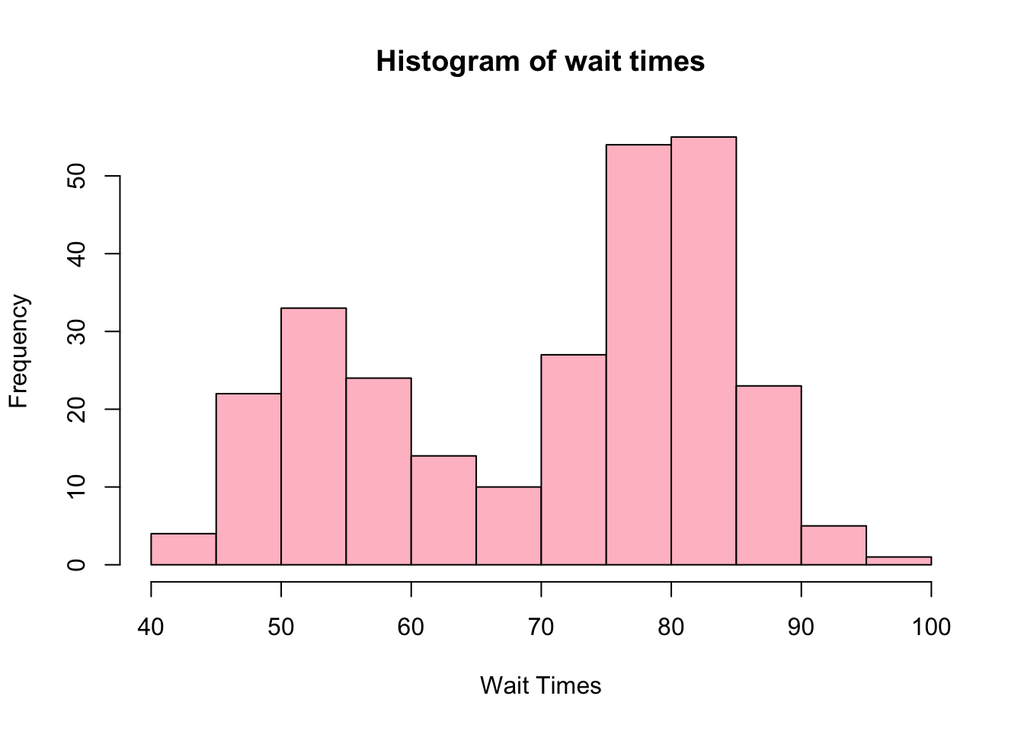

```r
#272 rows, 2 columns

#histogram of waiting times
hist(faithful$waiting, col = "pink", main = "Histogram of wait times", xlab = "Wait Times")
```

```r
#waiting time more than 70 mins
waiting_above_70 <- faithful[faithful$waiting > 70,]
waiting_above_70
```

```
##     eruptions waiting
## 1       3.600      79
## 3       3.333      74
## 5       4.533      85
## 7       4.700      88
## 8       3.600      85
## 10      4.350      85
## 12      3.917      84
## 13      4.200      78
## 15      4.700      83
## 18      4.800      84
## 20      4.250      79
## 23      3.450      78
## 25      4.533      74
## 26      3.600      83
```

[output cut: 151 more lines]

```r
#eruption less than 3 mins
erupt_below_3 <- waiting_above_70[waiting_above_70$eruptions < 3,]
erupt_below_3
```

```
##     eruptions waiting
## 211     2.383      71
```

```r
#row 211 - eruptions = 2.383 & waiting = 71

#compute conditional probability
conditional_prob <-nrow(erupt_below_3)/nrow(waiting_above_70)
conditional_prob
```

```
## [1] 0.006060606
```

```r
# 0.006060606
```

1. (3 points) Identify any observations in “faithful” for which the waiting time exceeds 70 minutes and the eruptions are less than 3.0 minutes. List and show any such observations in a distinct color on a scatterplot of all eruption (vertical axis) and waiting times (horizontal axis). Include a horizontal line at eruption = 3.0, and a vertical line at waiting time = 70. Add a title and appropriate text.

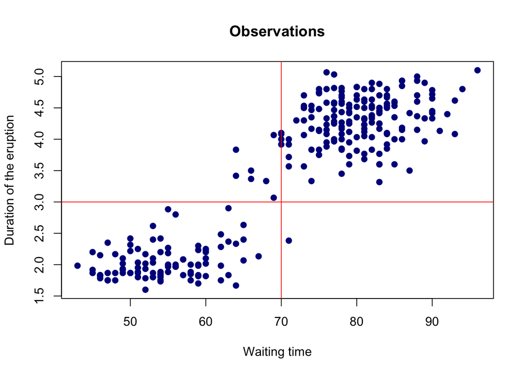

```r
plot(faithful$waiting, faithful$eruptions, main="Observations", xlab = "Waiting time",ylab = "Duration of the eruption", col = "dark blue", pch = 19)
abline(h=3,v=70,col="red")
```

2. (1.5 point) What does the plot suggest about the relationship between eruption time and waiting time?

*Answer: The scatter plot presents a positive correlation between duration of the eruptions and waiting time. Clusters in the lower and upper end of the correlation plot has also been observed, with a more scattered distribution in the mid range.*

(2)(b) (4.5 points) Past research indicates that the waiting times between consecutive eruptions are not independent. This problem will check to see if there is evidence of this. Form consecutive pairs of waiting times. In other words, pair the first and second waiting times, pair the third and fourth waiting times, and so forth. There are 136 resulting consecutive pairs of waiting times. Form a data frame with the first column containing the first waiting time in a pair and the second column with the second waiting time in a pair. Plot the pairs with the second member of a pair on the vertical axis and the first member on the horizontal axis.

One way to do this is to pass the vector of waiting times - faithful$waiting - to *matrix()*, specifying 2 columns for our matrix, with values organized by row; i.e. byrow = TRUE.

```r
matrix_waiting <- matrix(faithful$waiting,ncol=2,byrow=TRUE)
matrix_waiting
```

```
##        [,1] [,2]
##   [1,]   79   54
##   [2,]   74   62
##   [3,]   85   55
##   [4,]   88   85
##   [5,]   51   85
##   [6,]   54   84
##   [7,]   78   47
##   [8,]   83   52
##   [9,]   62   84
##  [10,]   52   79
##  [11,]   51   47
##  [12,]   78   69
##  [13,]   74   83
##  [14,]   55   76
```

[output cut: 122 more lines]

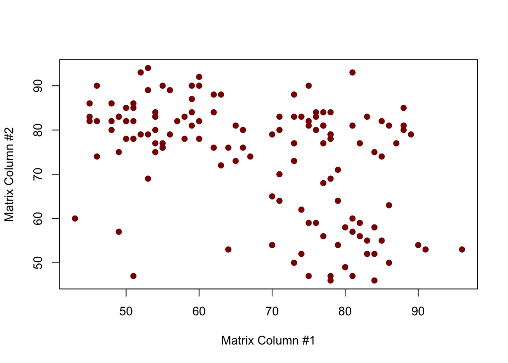

```r
plot(y=matrix_waiting[,2],x=matrix_waiting[,1], xlab = "Matrix Column #1", ylab = "Matrix Column #2", col="dark red", pch = 19)
```

(2)(c) (2) Test the hypothesis of independence with a two-sided test at the 5% level using the Kendall correlation coefficient.

```r
library(Kendall)
##
cor.test(matrix_waiting[,1],matrix_waiting[,2], alternative = "two.sided",method = "kendall", conf.level = 0.95)
```

```
##
##  Kendall's rank correlation tau
##
## data:  matrix_waiting[, 1] and matrix_waiting[, 2]
## z = -4.9482, p-value = 7.489e-07
## alternative hypothesis: true tau is not equal to 0
## sample estimates:
##        tau
## -0.2935579
```

##### Section 3: (15 points)

##### (3) Performing hypothesis tests using random samples is fundamental to statistical inference. The first part of this problem involves comparing two different diets. Using “ChickWeight” data available in the base R, “datasets” package, execute the following code to prepare a data frame for analysis.

```r
# load "ChickWeight" dataset
data(ChickWeight)

# Create T | F vector indicating observations with Time == 21 and Diet == "1" OR "3"
index <- ChickWeight$Time == 21 & (ChickWeight$Diet == "1" | ChickWeight$Diet == "3")

# Create data frame, "result," with the weight and Diet of those observations with "TRUE" "index"" values
result <- subset(ChickWeight[index, ], select = c(weight, Diet))

# Encode "Diet" as a factor
result$Diet <- factor(result$Diet)
str(result)
```

```
## Classes 'nfnGroupedData', 'nfGroupedData', 'groupedData' and 'data.frame':   26 obs. of  2 variables:
##  $ weight: num  205 215 202 157 223 157 305 98 124 175 ...
##  $ Diet  : Factor w/ 2 levels "1","3": 1 1 1 1 1 1 1 1 1 1 ...
```

##### The data frame, “result”, has chick weights for two diets, identified as diet “1” and “3”. Use the data frame, “result,” to complete the following item.

(3)(a) (3 points) Display two side-by-side vertical boxplots using par(mfrow = c(1,2)). One boxplot would display diet “1” and the other diet “3”.

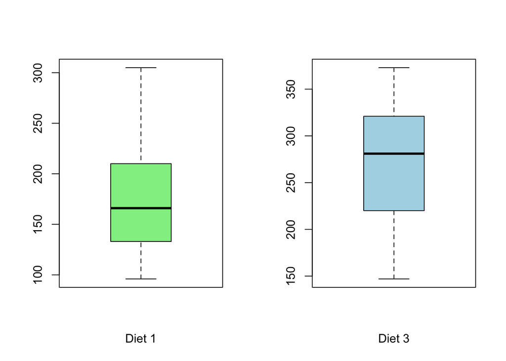

```r
par(mfrow=c(1,2))

#Diet = 1
result_1 <- result[result$Diet == "1",]
boxplot(result_1$weight, xlab = "Diet 1", col = "light green")

#Diet = 3
result_3 <- result[result$Diet == "3",]
boxplot(result_3$weight, xlab = "Diet 3", col = "light blue")
```

(3)(b) (3 points) Use the “weight” data for the two diets to test the null hypothesis of equal population mean weights for the two diets. Test at the 95% confidence level with a two-sided t-test. This can be done using *t.test()* in R. Assume equal variances. Display the results of t.test().

```r
t.test(result_1$weight,result_3$weight,alternative = "two.sided",conf.level = 0.95)
```

```
##
##  Welch Two Sample t-test
##
## data:  result_1$weight and result_3$weight
## t = -3.4293, df = 16.408, p-value = 0.003337
## alternative hypothesis: true difference in means is not equal to 0
## 95 percent confidence interval:
##  -149.64644  -35.45356
## sample estimates:
## mean of x mean of y
##    177.75    270.30
```

##### Working with paired data is another common statistical activity. The “ChickWeight” data will be used to illustrate how the weight gain from day 20 to 21 may be analyzed. Use the following code to prepare pre- and post-data from Diet == “3” for analysis.

```r
# load "ChickWeight" dataset
data(ChickWeight)

# Create T | F vector indicating observations with Diet == "3"
index <- ChickWeight$Diet == "3"

# Create vector of "weight" for observations where Diet == "3" and Time == 20
pre <- subset(ChickWeight[index, ], Time == 20, select = weight)$weight

# Create vector of "weight" for observations where Diet == "3" and Time == 21
post <- subset(ChickWeight[index, ], Time == 21, select = weight)$weight

# The pre and post values are paired, each pair corresponding to an individual chick.
cbind(pre, post)
```

```
##       pre post
##  [1,] 235  256
##  [2,] 291  305
##  [3,] 156  147
##  [4,] 327  341
##  [5,] 361  373
##  [6,] 225  220
##  [7,] 169  178
##  [8,] 280  290
##  [9,] 250  272
## [10,] 295  321
```

(3)(c) (3 points) Present a scatterplot of the variable “post” as a function of the variable “pre”. Include a diagonal line with zero intercept and slope equal to one. Title and label the variables in this scatterplot.

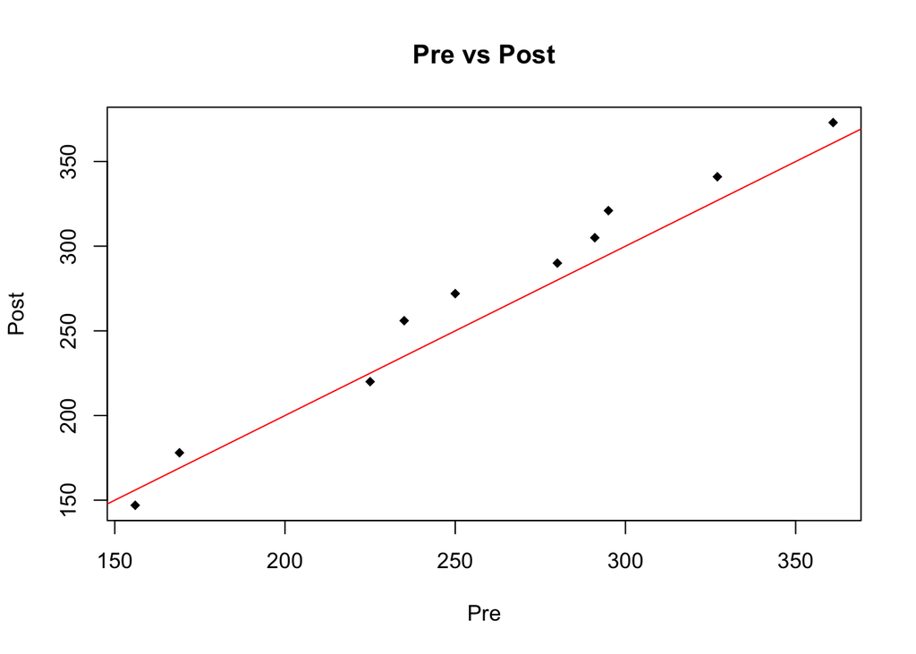

```r
plot(pre,post,col="black",xlab="Pre",ylab="Post",
main="Pre vs Post", pch=18)
abline(0,1,col="red")
```

(3)(d) (6 points) Calculate and present a one-sided, 95% confidence interval for the average weight gain from day 20 to day 21. Write the code for the paired t-test and for determination of the confidence interval endpoints. **Do not use *t.test()**, although you may check your answers using this function. Present the resulting test statistic value, critical value, p-value and confidence interval.

```r
a <- (post - pre)

#mean
mean_a <-mean(a)
#11.4

#length
l <- length(pre)
#10

#df
df <- l - 1
#9

#critical value
crit_value <- qt(0.05,df,lower.tail = FALSE)
#1.833113

#standard deviation
std_deviation <- sqrt(sum((a-mean_a)^2)/(l-1))
#11.17736

#standard error
std_error <- std_deviation/sqrt(l)
#3.534591

#t
t <- mean_a/std_error
#3.225267

#p-value
p_value <- pt(t,df,lower.tail = FALSE)
#0.00520061

#confidence interval
conf_int <-mean_a - crit_value * std_error
#4.920696

row_names<-c("Mean","Length", "df", "Critical Value", "Std Deviation", "Std Error", "t", "p-value", "Confidence Interval")
col_names<-c("Values")

matrix(c(mean_a, l, df, crit_value, std_deviation, std_error, t, p_value, conf_int), nrow = 9, ncol = 1, dimnames= list(row_names,col_names))
```

```
##                          Values
## Mean                11.40000000
## Length              10.00000000
## df                   9.00000000
## Critical Value       1.83311293
## Std Deviation       11.17735807
## Std Error            3.53459097
## t                    3.22526711
## p-value              0.00520061
## Confidence Interval  4.92069558
```

```r
##############################
t.test(post,pre, alternative = "greater", paired = TRUE, var.equal = TRUE, conf.level = 0.95)
```

```
##
##  Paired t-test
##
## data:  post and pre
## t = 3.2253, df = 9, p-value = 0.005201
## alternative hypothesis: true difference in means is greater than 0
## 95 percent confidence interval:
##  4.920696      Inf
## sample estimates:
## mean of the differences
##                    11.4
```

```r
#Paired t-test
#data:  post and pre
#t = 3.2253, df = 9, p-value = 0.005201
#alternative hypothesis: true difference in means is greater than 0
#95 percent confidence interval:
#4.920696      Inf
#sample estimates:
#mean of the differences
#                   11.4
```

##### Section 4: (15 points)

##### (4) Statistical inference depends on using a sampling distribution for a statistic in order to make confidence statements about unknown population parameters. The Central Limit Theorem is used to justify use of the normal distribution as a sampling distribution for statistical inference. Using Nile River flow data from 1871 to 1970, this problem demonstrates sampling distribution convergence to normality. Use the code below to prepare the data. Refer to this example when completing (4)(c) below.

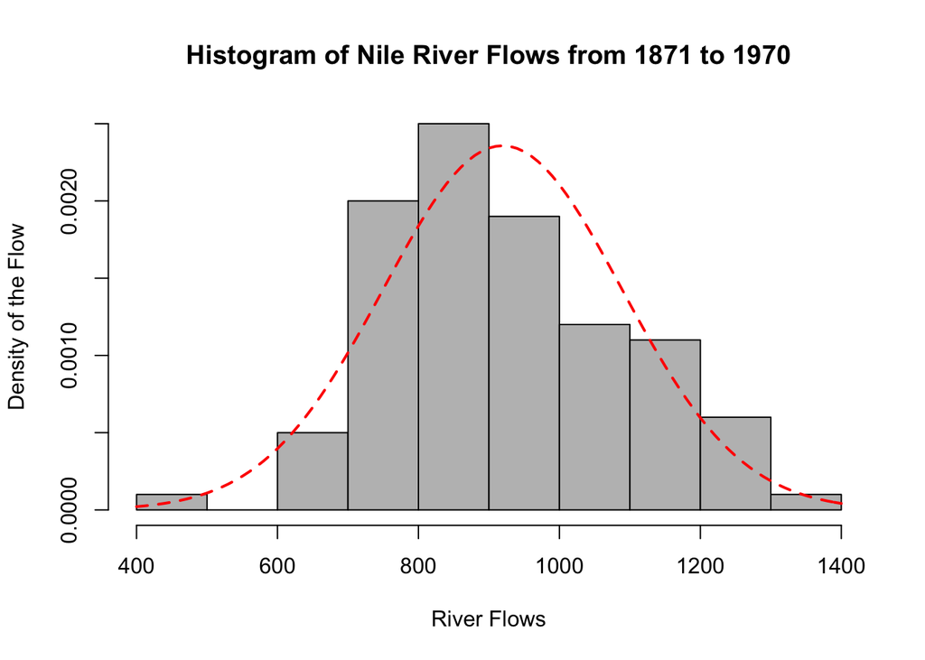

```r
data(Nile)
#mean
mean_Nile <- mean(Nile)
#standard deviation
std_Nile <- sd(Nile)

x <- seq(from = 400, to = 1400, by = 1)
hist(Nile, freq = FALSE, col = "gray", xlab = "River Flows", ylab = "Density of the Flow",
     main = "Histogram of Nile River Flows from 1871 to 1970")
curve(dnorm(x, mean = mean_Nile, sd = std_Nile), col = "red", lty = 2, lwd = 2, add = TRUE)
```

(4)(a) (3 points) Using Nile River flow data and the “moments” package, calculate skewness and kurtosis. Present a QQ plot and boxplot of the flow data side-by-side using *qqnorm()*, *qqline()* and *boxplot()*; *par(mfrow = c(1, 2))* may be used to locate the plots side-by-side. Add features to these displays as you choose.

```r
library(moments)

#skewness
skew_Nile <- skewness(Nile)
skew_Nile
```

```
## [1] 0.3223697
```

```r
#0.3223697

#kurtosis
kurt_Nile <- kurtosis(Nile)
kurt_Nile
```

```
## [1] 2.695093
```

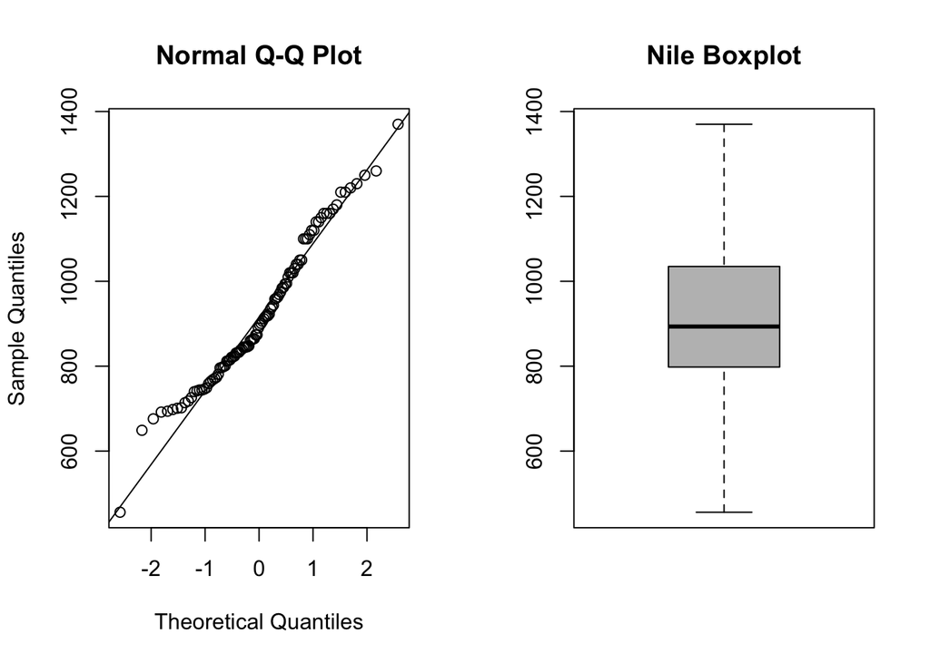

```r
#2.695093

par(mfrow=c(1,2))
qqnorm(Nile)
qqline(Nile)
boxplot(Nile, col = "gray", main = "Nile Boxplot")
```

(4)(b) (6 points) Using *set.seed(124)* and the Nile data, generate 1000 random samples of size n = 16, with replacement. For each sample drawn, calculate and store the sample mean. This can be done with a for-loop and use of the *sample()* function. Label the resulting 1000 mean values as “sample1”. **Repeat these steps using *set.seed(127)* - a different “seed” - and samples of size n = 64.** Label these 1000 mean values as “sample2”. Compute and present the means, sample standard deviations and sample variances for “sample1” and “sample2” in a table with the first row for “sample1”, the second row for “sample2” and the columns labled for each statistic.

```r
#for 124 with n=16 - sample 1
set.seed(124)
sample1<-rep(1:1000,0)
for(i in 1:1000) {
  sample1[i]<-mean(sample(Nile, 16, replace=TRUE))
}
######################

#for 127 with n=64 - sample 2
set.seed(127)
sample2<-rep(1:1000,0)

for(i in 1:1000) {
  sample2[i]<-mean(sample(Nile, 64, replace = TRUE))
}
######################

row_names<-c("Sample 1","Sample 2")
col_names<-c("Mean","St. Dev.","Variance")
#mean, standard deviation & variance
matrix(c(mean(sample1), mean(sample2), sd(sample1), sd(sample2), var(sample1), var(sample2)), nrow = 2, ncol = 3, dimnames= list(row_names,col_names))
```

```
##              Mean St. Dev. Variance
## Sample 1 918.7349 41.57159 1728.197
## Sample 2 919.4785 20.07329  402.937
```

(4)(c) (6 points) Present side-by-side histograms of “sample1” and “sample2” with the normal density curve superimposed. To prepare comparable histograms, it will be necessary to use “freq = FALSE” and to maintain the same x-axis with “xlim = c(750, 1050)”, and the same y-axis with “ylim = c(0, 0.025).” **To superimpose separate density functions, you will need to use the mean and standard deviation for each “sample” - each histogram - separately.**

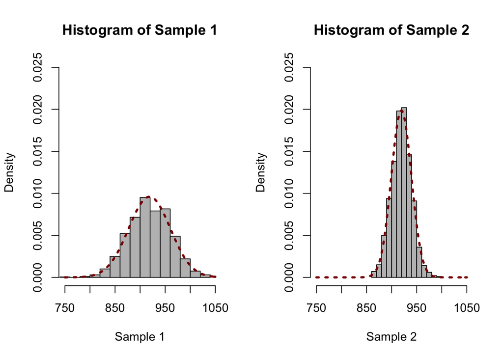

```r
par(mfrow=c(1,2))

hist(sample1, freq = FALSE, xlim = c(750, 1050), ylim = c(0, 0.025), col = "gray", main = "Histogram of Sample 1", xlab = "Sample 1")
curve(dnorm(x, mean = mean(sample1), sd = sd(sample1)), add=TRUE, col="dark red", lty=3, lwd=3)

hist(sample2, freq = FALSE, xlim = c(750, 1050), ylim = c(0, 0.025), col = "gray", main = "Histogram of Sample 2", xlab = "Sample 2")
curve(dnorm(x, mean = mean(sample2), sd = sd(sample2)), add=TRUE, col="dark red", lty=3, lwd=3)
```

##### Section 5: (15 points)

##### (5) This problem deals with contingency table analysis. This is an example of categorical data analysis (see Kabacoff, pp. 145-151). The “warpbreaks” dataset gives the number of warp breaks per loom, where a loom corresponds to a fixed length of yarn. There are 54 observations on 3 variables: breaks (numeric, the number of breaks), wool (factor, type of wool: A or B), and tension (factor, low L, medium M and high H). These data have been studied and used for example elsewhere. For the purposes of this problem, we will focus on the relationship between breaks and tension using contingency table analysis.

(5)(a)(4.5 points) warpbreaks is part of the “datasets” package and may be loaded via *data(warpbreaks)*. Load “warpbreaks” and present the structure using *str()*. Calculate the median number of breaks for the entire dataset, disregarding “tension” and “wool”. Define this median value as “median_breaks”. Present a histogram of the number of breaks with the location of the median indicated.

Create a new variable “number” as follows: for each value of “breaks”, classify the number of breaks as either strictly below “median_breaks”, or the alternative. Convert the “above”|“below” classifications to a factor, and combine with the dataset warpbreaks. Present a summary of the augmented dataset using *summary()*. Present a contingency table of the frequency of breaks using the two variables “tension” and “number”. There should be six cells in this table.

```r
#exploratory
data(warpbreaks)
summary(warpbreaks)
```

```
##      breaks      wool   tension
##  Min.   :10.00   A:27   L:18
##  1st Qu.:18.25   B:27   M:18
##  Median :26.00          H:18
##  Mean   :28.15
##  3rd Qu.:34.00
##  Max.   :70.00
```

```r
str(warpbreaks)
```

```
## 'data.frame':    54 obs. of  3 variables:
##  $ breaks : num  26 30 54 25 70 52 51 26 67 18 ...
##  $ wool   : Factor w/ 2 levels "A","B": 1 1 1 1 1 1 1 1 1 1 ...
##  $ tension: Factor w/ 3 levels "L","M","H": 1 1 1 1 1 1 1 1 1 2 ...
```

```r
#54 rows, 3 columns

#calculate median with only $breaks
median_breaks <- median(warpbreaks$breaks)
median_breaks
```

```
## [1] 26
```

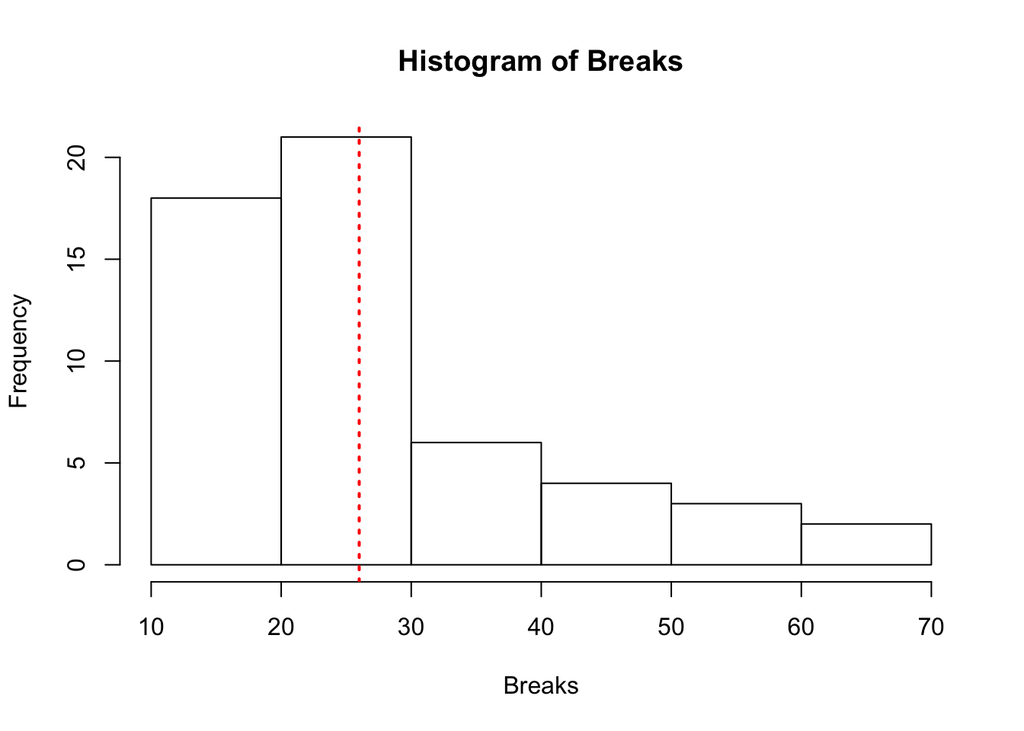

```r
#median is 26

#plot histogram with median
hist(warpbreaks$breaks, main = "Histogram of Breaks", xlab = "Breaks")
abline(v= median(warpbreaks$breaks), col="red", lty= 3, lwd= 2)
```

```r
#"above" & "below" classification
warpbreaks$number <-ifelse(warpbreaks$breaks<median_breaks,"below","above")
warpbreaks$number
```

```
##  [1] "above" "above" "above" "below" "above" "above" "above" "above"
##  [9] "above" "below" "below" "above" "below" "below" "below" "above"
## [17] "above" "above" "above" "below" "below" "below" "below" "above"
## [25] "above" "below" "above" "above" "below" "above" "below" "above"
## [33] "above" "above" "below" "above" "above" "above" "below" "below"
## [41] "above" "above" "below" "above" "above" "below" "below" "below"
## [49] "below" "below" "below" "below" "below" "above"
```

```r
#contingency table with $tension and $number
contingency_table <- table(warpbreaks$tension,warpbreaks$num)
contingency_table
```

```
##
##     above below
##   L    14     4
##   M    10     8
##   H     5    13
```

```r
# 3x2 = 6 cells total
```

(5)(b)(3 points) Using the table constructed in (5)(a), test at the 5% level the null hypothesis of independence using the uncorrected *chisq.test()* (Black, Business Statistics, Section 16.2). Show the results of this test and state your conclusions.

```r
#chi-square test on contingency table
chisq.test(contingency_table)
```

```
##
##  Pearson's Chi-squared test
##
## data:  contingency_table
## X-squared = 9.0869, df = 2, p-value = 0.01064
```

(5)(c) (7.5 points) Write a function that computes the uncorrected Pearson Chi-squared statistic. Apply your function to the table from (5)(a). You should be able to duplicate the X-squared value (chi-squared) and *p*-value. Present both.

Shown below are examples of the type of function required. These examples will have to be modified to accomodate the table generated in (5)(a).

```r
chi <- function(x) {
# To be used with 2x2 contingency tables that have margins added.
# Expected values are calculated.
     e11 <- x[4,1]*x[1,3]/x[4,3]
     e12 <- x[4,2]*x[1,3]/x[4,3]
     e21 <- x[4,1]*x[2,3]/x[4,3]
     e22 <- x[4,2]*x[2,3]/x[4,3]
     e31 <- x[4,1]*x[3,3]/x[4,3]
     e32 <- x[4,2]*x[3,3]/x[4,3]

# Value of chi square statistic is calculated.
     chisqStat <- (x[1,1] - e11)^2 / e11 + (x[1,2] - e12)^2 / e12 + (x[2,1] -        e21)^2 / e21 + (x[2,2] - e22)^2 / e22 + (x[3,1] - e31)^2 / e31 +              (x[3,2] - e32)^2 / e32
     return(list("chi-squared" = chisqStat,
                 "p-value" = pchisq(chisqStat, 2, lower.tail = F)))
}

b <- addmargins(contingency_table)
chi(b)
```

```
## $`chi-squared`
## [1] 9.086897
##
## $`p-value`
## [1] 0.01063667
```

```r
#########
chisqfun <- function(t) {
   x <- addmargins(t)
   e <- matrix(0, nrow = nrow(t), ncol = ncol(t), byrow = T)
   r <- matrix(0, nrow = nrow(t), ncol = ncol(t), byrow = T)
   for (i in 1:3) {
       for (j in 1:2) {
          e[i,j] = x[nrow(x),j] * x[i,ncol(x)]/x[nrow(x), ncol(x)]
         r[i,j] = ((x[i,j] - e[i,j])^2)/e[i,j]
         }
     }
  chi <- sum(r)
  xdf <- nrow(t) - 1
  pv <- pchisq(chi, df = xdf, lower.tail = FALSE)
 return(cat("Pearson's Chi-squared test \\n","Chi sq: ", chi, ";
            Degree of Freedom :",xdf," ; P-value :",pv))
}

chisqfun(contingency_table)
```

```
## Pearson's Chi-squared test \n Chi sq:  9.086897 ;
##             Degree of Freedom : 2  ; P-value : 0.01063667
```